# Final Project STAT442

Chaozhong Wang

2025-04-13

## Option 1

```r
library(tidyverse)
library(lubridate)
library(ggrepel)  # For better label placement

# Prepare data with correct quarterly dates
trade_data <- read_csv("dataset_2025-04-13T02_01_49.813546073Z_DEFAULT_INTEGRATION_IMF.STA_IMTS_1.0.0.csv") %>%
  separate(TIME_PERIOD, into = c("Year", "Quarter"), sep = "-Q", remove = FALSE) %>%
  mutate(
    Year = as.integer(Year),
    Quarter = as.integer(Quarter),
    Date = ymd(paste(Year, Quarter * 3 - 2, "01"))  # First day of quarter
  )
```

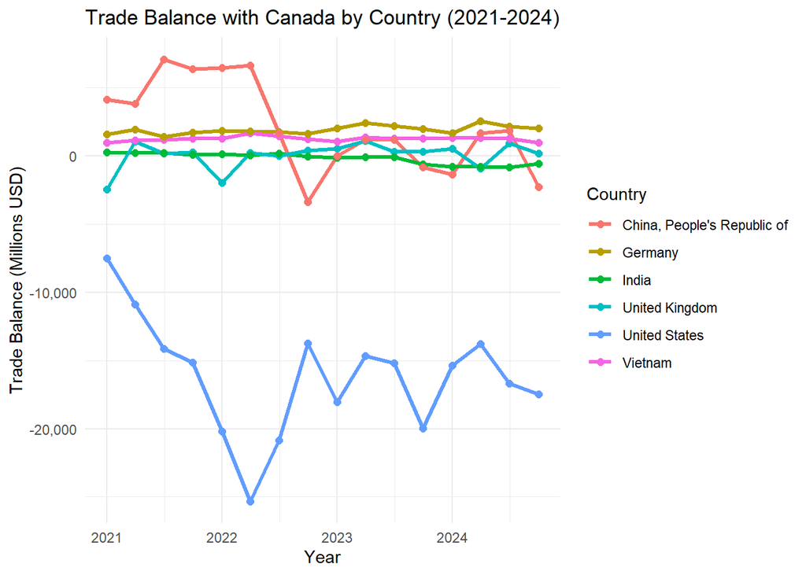

```r
# Identify extreme countries (top/bottom 3 by average absolute trade balance)
extreme_countries <- c("United States",
                       "China, People's Republic of",
                       "Germany",
                       "India",
                       "United Kingdom",
                       "Vietnam"

)

# Create labeled time series plot
ggplot(trade_data %>% filter(COUNTRY %in% extreme_countries),
       aes(x = Date, y = OBS_VALUE/1e6, color = COUNTRY)) +
  geom_line(linewidth = 1.2) +
  geom_point(size = 2) +
  theme_minimal() +
    scale_y_continuous(labels = scales::comma) +
  labs(title = "Trade Balance with Canada by Country (2021-2024)",
       x = "Year",
       y = "Trade Balance (Millions USD)",
       color = "Country")
```

The line plot gives us an overview of the trade balance data over the past 4 years.

Canada’s trade relationships show striking imbalances, with the United States dominating deficits and China leading surpluses.

Stable partners: Vietnam/Germany maintain consistent surpluses.

## Option 2

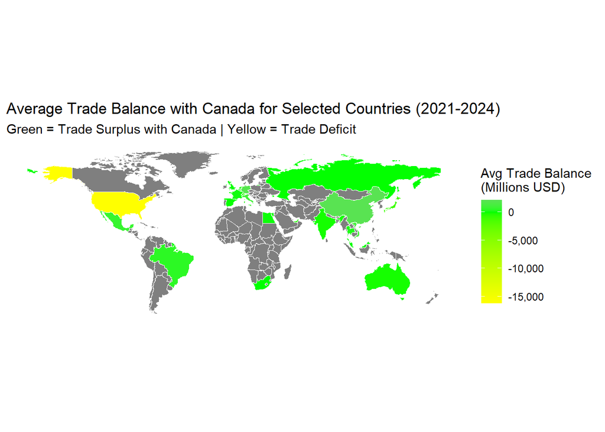

```r
# Load necessary libraries
library(tidyverse)
library(ggplot2)
library(maps)        # For world map data
library(countrycode) # For country name standardization
library(sf)          # For spatial data handling
library(rnaturalearth) # For high-resolution world maps
library(viridis)     # For color scales
data = read_csv("dataset_2025-04-13T02_01_49.813546073Z_DEFAULT_INTEGRATION_IMF.STA_IMTS_1.0.0.csv")
# Standardize country names to match map data
data <- data %>%
   mutate(COUNTRY = case_when(
     COUNTRY == "China, People's Republic of" ~ "China",
     COUNTRY == "Hong Kong Special Administrative Region, People's Republic of" ~ "Hong Kong",
     COUNTRY == "Netherlands, The" ~ "Netherlands",
     COUNTRY == "Egypt, Arab Republic of" ~ "Egypt",
     TRUE ~ COUNTRY
   ))

# #add continent information
# data <- data %>%
#   mutate(continent = countrycode(COUNTRY, "country.name", "continent",
#                               custom_match = c("Hong Kong" = "Asia")))

# Get world map data
world <- ne_countries(scale = "medium", returnclass = "sf") %>%
  filter(name != "Antarctica")

#repare trade data for mapping (using average trade balance for each country)
trade_summary <- data %>%
  group_by(COUNTRY) %>%
   summarize(avg_trade = mean(OBS_VALUE/1e6, na.rm = TRUE)) %>% ungroup()

# Join trade data with map data
world_trade <- world %>%
  left_join(trade_summary, by = c("name_long" = "COUNTRY"))


# Choropleth Map of Average Trade Balance
ggplot(world_trade) +
  geom_sf(aes(fill = avg_trade), color = "white", size = 0.2) +
  scale_fill_gradient2(low = "yellow", mid = "green", high = "blue",
                      midpoint = 0,
                      labels = scales::comma,
                      name = "Avg Trade Balance\n(Millions USD)") +
  labs(title = "Average Trade Balance with Canada for Selected Countries (2021-2024)",
       subtitle = "Green = Trade Surplus with Canada | Yellow = Trade Deficit") +
  theme_minimal() +
  theme(legend.position = "right",
        axis.text = element_blank(),
        panel.grid = element_blank())
```

China has a trade surplus with Canada an average over 2021 - 2024.

The United States has a trade deficit with Canada an average over 2021 - 2024.

Most countries have a trade balance around 0 with Canada.

## Option 3

[figure not shown]

```r
#by continent
# Load libraries
library(tidyverse)
library(ggplot2)
library(countrycode)
library(viridis)
library(ggrepel) # For better label placement


data <- data %>%
    separate(TIME_PERIOD, into = c("Year", "Quarter"), sep = "-Q", remove = FALSE) %>%
  mutate(
    Year = as.integer(Year),
    Quarter = as.integer(Quarter),
    Date = ymd(paste(Year, Quarter * 3 - 2, "01"))  # First day of quarter
  ) %>%
  mutate(continent = countrycode(COUNTRY, "country.name", "continent",
                               custom_match = c(
                                 "Hong Kong" = "Asia",
                                 "Kosovo" = "Europe",
                                 "Taiwan" = "Asia"))) %>%
  # Handle any remaining NA continents
  mutate(continent = case_when(
    COUNTRY == "European Union" ~ "Europe",
    TRUE ~ continent
  )) %>%
  filter(!is.na(continent)) # Remove any countries without continent classification
continent_palette <- c("#440154FF", "#433E85FF", "#2E6F8EFF", "#1F9A8AFF", "#4DC36BFF", "#BBDF27FF")
# Stacked Area Chart of Continental Aggregates
continent_totals <- data %>%
  group_by(Date, continent) %>%
  summarize(total_trade = sum(OBS_VALUE, na.rm = TRUE)/1000) %>%
  mutate(continent = fct_reorder(continent, -total_trade, .fun = sum))
ggplot(continent_totals, aes(x = Date, y = total_trade, fill = continent)) +
  geom_area(alpha = 0.8) +
  scale_fill_manual(values = continent_palette) +
  scale_y_continuous(labels = scales::comma) +
  labs(title = "Aggregate Trade Balance with Canada by Continent",
       subtitle = "Stacked area shows combined trade balance for all countries in each continent",
       x = "Year",
       y = "Total Trade Balance (Millions USD)",
       fill = "Continent") +
  theme_minimal() +
  theme(legend.position = "bottom")
```

## Option 5

```r
library(tidyverse)
library(knitr)
library(formattable)

# Read and prepare data with volatility calculations
volatility_data <- read_csv("CAtrading(countryperrow).csv") %>%
  pivot_longer(
    cols = `2021-Q1`:`2024-Q4`,
    names_to = "Quarter",
    values_to = "Trade_Balance"
  ) %>%
  group_by(COUNTRY, CONTINENT) %>%
  summarise(
    Avg_Balance = mean(Trade_Balance),
    Volatility = sd(Trade_Balance),
    Min_Balance = min(Trade_Balance),
    Max_Balance = max(Trade_Balance),
    .groups = "drop"
  ) %>%
  mutate(
    Volatility_Level = case_when(
      Volatility > 1500 ~ "Extreme",
      Volatility > 500 ~ "High",
      Volatility > 100 ~ "Moderate",
      TRUE ~ "Low"
    ),
    Balance_Type = ifelse(Avg_Balance >= 0, "Surplus", "Deficit")
  ) %>%
  arrange(desc(Volatility))
colnames(volatility_data) <- c(
  "COUNTRY",
  "CONTINENT",
  "Avg Balance",
  "Volatility",
  "Min Balance",
  "Max Balance",
  "Volatility Level",
  "Balance Type"
)
# Create conditional formatting table
formattable(volatility_data, list(
  `COUNTRY` = formatter("span", style = ~ style(color = "grey", font.weight = "bold")),
  `Volatility` = color_tile("white", "red"),
  `Avg Balance` = formatter("span",
    style = x ~ style(
      color = ifelse(x >= 0, "green", "red"),
      font.weight = ifelse(abs(x) > 1000, "bold", "normal")
    ),
    x ~ accounting(x, digits = 0)
  ),
  `Volatility Level` = formatter("span",
    style = x ~ style(
      display = "block",
      padding = "0 4px",
      "border-radius" = "4px",
      "background-color" = case_when(
        x == "Extreme" ~ "#FF0000",
        x == "High" ~ "#FF6B6B",
        x == "Moderate" ~ "#FFD166",
        TRUE ~ "#CCE5FF"
      )
    )
  ),
  `Balance Type` = formatter("span",
    style = x ~ style(
      display = "block",
      padding = "0 4px",
      "border-radius" = "4px",
      "background-color" = ifelse(x == "Surplus", "#C7F5C7", "#FFC7C7")
    ))),
  caption = "Trade Balance Volatility with Canada (2021-2024), unit in Million")
```

Trade Balance Volatility with Canada (2021-2024), unit in Million

| COUNTRY | CONTINENT | Avg Balance | Volatility | Min Balance | Max Balance | Volatility Level | Balance Type |
| --- | --- | --- | --- | --- | --- | --- | --- |
| United States | North America | (16,184) | 4205.34076 | -25313.86886 | -7499.17703 | Extreme | Deficit |
| China | Asia | 2,137 | 3329.19318 | -3389.91985 | 7091.61009 | Extreme | Surplus |
| United Kingdom | Europe | 46 | 1002.38287 | -2457.44803 | 1111.78193 | High | Surplus |
| Switzerland | Europe | (472) | 785.39286 | -1981.63523 | 401.94088 | High | Deficit |
| Japan | Asia | (1,160) | 721.83696 | -2277.89912 | -88.10894 | High | Deficit |
| Mexico | North America | 753 | 567.36766 | 0.98652 | 1703.72728 | High | Surplus |
| Brazil | South America | 477 | 443.91446 | -496.69164 | 1258.75131 | Moderate | Surplus |
| Hong Kong, China | Asia | (319) | 425.15219 | -1027.82946 | 205.80811 | Moderate | Deficit |
| India | Asia | (163) | 400.86876 | -813.89594 | 289.69416 | Moderate | Deficit |
| Netherlands | Europe | (244) | 311.48411 | -720.55324 | 140.44646 | Moderate | Deficit |
| Germany | Europe | 1,918 | 303.78346 | 1389.71385 | 2537.45708 | Moderate | Surplus |
| Italy | Europe | 1,037 | 246.64009 | 540.90463 | 1422.54559 | Moderate | Surplus |
| Belgium | Europe | 51 | 231.20819 | -343.30847 | 473.07363 | Moderate | Surplus |
| Vietnam | Asia | 1,253 | 178.74932 | 953.47350 | 1661.31069 | Moderate | Surplus |
| Singapore | Asia | (283) | 162.42306 | -718.30272 | -116.04028 | Moderate | Deficit |
| Australia | Oceania | (173) | 118.11889 | -464.57601 | 32.25703 | Moderate | Deficit |
| Spain | Europe | (37) | 116.22508 | -264.74295 | 173.74087 | Moderate | Deficit |
| United Arab Emirates | Asia | (576) | 108.20138 | -710.80199 | -364.76747 | Moderate | Deficit |
| France | Europe | 113 | 102.24455 | -40.73357 | 321.92228 | Moderate | Surplus |
| Egypt | Africa | 78 | 97.32543 | -134.62557 | 179.89399 | Low | Surplus |
| Malaysia | Asia | 55 | 94.32332 | -83.21521 | 233.03294 | Low | Surplus |
| Russian Federation | Europe | (20) | 44.26281 | -111.92830 | 56.74228 | Low | Deficit |
| Thailand | Asia | 234 | 37.78726 | 143.02344 | 299.70995 | Low | Surplus |
| South Africa | Africa | 4 | 35.60602 | -91.49994 | 45.15841 | Low | Surplus |

Countries are sorted by volatility, the amount of change. U.S. has the most volatility, followed by China.